# Genomic Rearrangement, Copy Number Alteration, and Mutual Exclusivity

sho

2020 7 24

# I. Overview

## 1. Load libraries and Data (via cBio Portal CGDSR)

### 1-1. Install Rtools (for compiling R packages from source)

First, install Rtools from binary. The link is as follows; https://cran.r-project.org/bin/windows/Rtools/.

After installing Rtools, type the following into the R console in order to associate PATH variables to the simulated R-bash environment’s executable binaries, such as `make`.

I downgraded from rtool40 to rtools35 because R itself downgraded from 4.0.2 to 3.6.3 for compatibility with “DISCOVER” package, which is not yet released for versions 4.0.0 or higher.

```
writeLines('PATH="C:\\rtools35\\usr\\bin;${PATH}"', con="~/.Renviron")
```

```r
Sys.which("make")
```

```
##            make
## "/usr/bin/make"
```

### 1-2. Install `discover` package/dependencies and other required tools.

We need following libraries: - discover: `DISCOVER` is a tool for calculating co-occurrences and mutual exclusivity, as described in [“A novel independence test for somatic alterations in cancer shows that biology drives mutual exclusivity but chance explains co-occurrence.”](https://genomebiology.biomedcentral.com/articles/10.1186/s13059-016-1114-x) - `cgdsr`: This is an R-based API(application programming interface) for downloading and processing the right data from CGDS (Cancer Genomics Data Server). https://cran.r-project.org/web/packages/cgdsr/index.html - `maftools`: “Summarize, Analyze and Visualize MAF Files and get insight into the somatic variants” https://www.bioconductor.org/packages/release/bioc/vignettes/maftools/inst/doc/maftools.html - `cometExactTest`(Exact Test from the **Co**mbinations of **M**utually **E**xclusive Al**t**erations): Statistical algorithm for identifying combinations of mutually exclusive alterations in cancer genomes. https://cran.r-project.org/web/packages/cometExactTest/index.html

There’s no “DISCOVER” package for R4.0.0 or up. Therefore it seems that I have to resort to downgrading or install separate version of R 3.6.~.

```r
options(repos=c(getOption("repos"), "http://ccb.nki.nl/software/discover/repos/r"))
install.packages("discover")
```

There’s also option of installing package from locally downloaded source file.

Then I installed `cgdsr` package.

In order to install `maftools` and `cometExactTest`, I need `BiocManager`.

### 1-3. Load libraries

```r
library(discover)
library(cgdsr)
library(maftools)
library(cometExactTest)
```

## 2. Form Binary Mutation Matrix from Somatic Mutation and CNA data from *cBio Portal CGDSR*

### 2-1. Get study list. (classified by `cancer_study_id`, `name`, `description`)

```r
# Call Library and cBioPortal
cbiop <- CGDS('http://www.cbioportal.org/')
```

```r
#study list identification
getCancerStudies(cbiop)
```

```
##                       cancer_study_id
## 1                       paac_jhu_2014
## 2                 mel_tsam_liang_2017
## 3                     all_stjude_2015
## 4                     all_stjude_2016
## 5                       aml_ohsu_2018
## 6                           laml_tcga
## 7                       laml_tcga_pub
## 8        laml_tcga_pan_can_atlas_2018
## 9                      mnm_washu_2016
## 10                      acyc_fmi_2014
## 11                      acyc_jhu_2016
## 12                      acyc_mda_2015
## 13                      acyc_mgh_2016
## 14                    acyc_mskcc_2013
```

[output cut: 852 more lines]

```r
names(getCancerStudies(cbiop))
```

```
## [1] "cancer_study_id" "name"            "description"
```

```r
getCancerStudies(cbiop)$cancer_study_id
```

```
##   [1] "paac_jhu_2014"                     "mel_tsam_liang_2017"
##   [3] "all_stjude_2015"                   "all_stjude_2016"
##   [5] "aml_ohsu_2018"                     "laml_tcga"
##   [7] "laml_tcga_pub"                     "laml_tcga_pan_can_atlas_2018"
##   [9] "mnm_washu_2016"                    "acyc_fmi_2014"
##  [11] "acyc_jhu_2016"                     "acyc_mda_2015"
##  [13] "acyc_mgh_2016"                     "acyc_mskcc_2013"
##  [15] "acyc_sanger_2013"                  "acc_2019"
##  [17] "acbc_mskcc_2015"                   "acc_tcga"
##  [19] "acc_tcga_pan_can_atlas_2018"       "sarc_tcga_pub"
##  [21] "ampca_bcm_2016"                    "odg_msk_2017"
##  [23] "bcc_unige_2016"                    "blca_mskcc_solit_2014"
##  [25] "blca_mskcc_solit_2012"             "blca_plasmacytoid_mskcc_2016"
##  [27] "blca_tcga_pub_2017"                "blca_bgi"
##  [29] "blca_dfarber_mskcc_2014"           "blca_tcga"
```

[output cut: 129 more lines]

```r
getCancerStudies(cbiop)$name
```

```
##   [1] "Acinar Cell Carcinoma of the Pancreas (JHU, J Pathol 2014)"
##   [2] "Acral Melanoma (TGEN, Genome Res 2017)"
##   [3] "Acute Lymphoblastic Leukemia (St Jude, Nat Genet 2015)"
##   [4] "Acute Lymphoblastic Leukemia (St Jude, Nat Genet 2016)"
##   [5] "Acute Myeloid Leukemia (OHSU, Nature 2018)"
##   [6] "Acute Myeloid Leukemia (TCGA, Firehose Legacy)"
##   [7] "Acute Myeloid Leukemia (TCGA, NEJM 2013)"
##   [8] "Acute Myeloid Leukemia (TCGA, PanCancer Atlas)"
##   [9] "Acute myeloid leukemia or myelodysplastic syndromes (WashU, 2016)"
##  [10] "Adenoid Cystic Carcinoma (FMI, Am J Surg Pathl. 2014)"
##  [11] "Adenoid Cystic Carcinoma (JHU, Cancer Prev Res 2016)"
##  [12] "Adenoid Cystic Carcinoma (MDA, Clin Cancer Res 2015)"
##  [13] "Adenoid Cystic Carcinoma (MGH, Nat Gen 2016)"
##  [14] "Adenoid Cystic Carcinoma (MSKCC, Nat Genet 2013)"
##  [15] "Adenoid Cystic Carcinoma (Sanger/MDA, JCI 2013)"
```

[output cut: 273 more lines]

```r
getCancerStudies(cbiop)$description
```

```
##   [1] "Whole exome sequencing of 23 surgically resected pancreatic carcinomas with acinar differentiation and their matched normals."
##   [2] "Whole exome sequencing and transcriptome analysis of 34 Acral Melanoma patients (33 with matched normals)."
##   [3] "Comprehensive profiling of infant MLL-rearranged acute lymphoblastic leukemia (MLL-R ALL)"
##   [4] "Whole-genome and/or whole-exome sequencing of ERG-altered B-ALL tumor/normal pairs."
##   [5] "Whole-exome sequencing of 672 acute myeloid leukemia samples (with 454 matched normals) from the Beat AML program."
##   [6] "TCGA Acute Myeloid Leukemia; raw data at the <A HREF=\"https://tcga-data.nci.nih.gov/\">NCI</A>; source mutation data from <a HREF=\"http://gdac.broadinstitute.org/runs/stddata__2016_01_28/data/LAML/20160128/gdac.broadinstitute.org_LAML.Mutation_Packager_Calls.Level_3.2016012800.0.0.tar.gz…
##   [7] "Whole-genome or whole-exome sequencing analysis of 200 adult de novo AML tumor/normal pairs. TCGA Acute Myeloid Leukemia Project; raw data at the <A HREF=\"https://tcga-data.nci.nih.gov/tcga/tcgaCancerDetails.jsp?diseaseType=LAML&diseaseName=Acute%20Myeloid%20Leukemia\">NCI</A>."
##   [8] "Acute Myeloid Leukemia TCGA PanCancer data. The original data is <a href=\"https://gdc.cancer.gov/about-data/publications/pancanatlas\">here</a>. The publications are <a href=\"https://www.cell.com/pb-assets/consortium/pancanceratlas/pancani3/index.html\">here</a>."
##   [9] "Enhanced exome or targeted sequencing of 116 acute myeloid leukemia (AML) or myelodysplastic syndromes (MDS) patients' tumor/normal pairs ."
##  [10] "Comprehensive genomic profiling of 28 metastatic ACCs."
##  [11] "Whole-genome or whole-exome sequencing of 25 adenoid cystic carcinoma tumor/normal pairs."
##  [12] "WGS of 21 salivary ACCs and targeted molecular analyses of a validation set (81 patients)."
##  [13] "Whole-genome/exome sequencing of 10 ACC PDX models."
##  [14] "Whole-exome or whole-genome sequencing analysis of 60 ACC tumor/normal pairs"
##  [15] "Whole exome sequencing of 24 ACCs."
```

[output cut: 273 more lines]

```r
getCancerStudies(cbiop)[1:5,1:2]
```

```
##       cancer_study_id
## 1       paac_jhu_2014
## 2 mel_tsam_liang_2017
## 3     all_stjude_2015
## 4     all_stjude_2016
## 5       aml_ohsu_2018
##                                                         name
## 1 Acinar Cell Carcinoma of the Pancreas (JHU, J Pathol 2014)
## 2                     Acral Melanoma (TGEN, Genome Res 2017)
## 3     Acute Lymphoblastic Leukemia (St Jude, Nat Genet 2015)
## 4     Acute Lymphoblastic Leukemia (St Jude, Nat Genet 2016)
## 5                 Acute Myeloid Leukemia (OHSU, Nature 2018)
```

### 2-2. Select Study

```r
study <- "laml_tcga"

getCaseLists(cbiop, study)
```

```
##                   case_list_id                        case_list_name
## 1                laml_tcga_all                           All samples
## 2      laml_tcga_3way_complete                      Complete samples
## 3                laml_tcga_cna                 Samples with CNA data
## 4    laml_tcga_methylation_all         Samples with methylation data
## 5   laml_tcga_methylation_hm27  Samples with methylation data (HM27)
## 6  laml_tcga_methylation_hm450 Samples with methylation data (HM450)
## 7    laml_tcga_rna_seq_v2_mrna   Samples with mRNA data (RNA Seq V2)
## 8       laml_tcga_rna_seq_mrna      Samples with mRNA data (RNA Seq)
## 9             laml_tcga_cnaseq    Samples with mutation and CNA data
## 10         laml_tcga_sequenced            Samples with mutation data
##                                           case_list_description cancer_study_id
## 1                                     All samples (200 samples)            2233
## 2  Samples with mutation, CNA and expression data (163 samples)            2233
## 3                           Samples with CNA data (191 samples)            2233
```

[output cut: 18 more lines]

Among these case list id’s, select `laml_tcga_sequenced`.

```r
cases <- "laml_tcga_sequenced"
```

### 2-3. Get available genetic profiles

```r
getGeneticProfiles(cbiop, study)
```

```
##                                     genetic_profile_id
## 1                                     laml_tcga_gistic
## 2                               laml_tcga_rna_seq_mrna
## 3                            laml_tcga_rna_seq_v2_mrna
## 4             laml_tcga_rna_seq_v2_mrna_median_Zscores
## 5                                 laml_tcga_linear_CNA
## 6                           laml_tcga_methylation_hm27
## 7                          laml_tcga_methylation_hm450
## 8                                  laml_tcga_mutations
## 9  laml_tcga_rna_seq_v2_mrna_median_all_sample_Zscores
## 10    laml_tcga_rna_seq_mrna_median_all_sample_Zscores
##                                                      genetic_profile_name
## 1                            Putative copy-number alterations from GISTIC
## 2                                          mRNA expression (RNA Seq RPKM)
## 3                                       mRNA expression (RNA Seq V2 RSEM)
```

[output cut: 29 more lines]

```r
genProf = getGeneticProfiles(cbiop, study)
```

### 2-4. Select specific data you want

```r
variable1 <- "laml_tcga_mutations"
variable2 <- "laml_tcga_linear_CNA"
```

### 2-5. aml driver gene upload (AML = Acute Myelogenous Leukemia)

```r
d_gene<-read.table("aml_drivergene.txt", stringsAsFactors=F)
```

### 2-6. Somatic Mutation Data and CNV Data Loading

```r
somatic <- getMutationData(cbiop, cases, variable1, as.list(d_gene)$V1)
cnv <- getProfileData(cbiop, as.list(d_gene)$V1, variable2, cases)
```

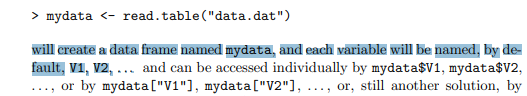

### 2-7. Building a Binary Mutation Matrix

1 - mutation / 0 - Wildtype

If CNV goes higher than 0.1, CNV is considered +1, and if CNV is less than -0.1, it’s considered -1. And if in between, CNV is considered 0.

```r
# Copy Number Processing

na.omit_cnv <- na.omit(cnv)
for (j in 1:ncol(na.omit_cnv)){
  for (i in 1:nrow(na.omit_cnv)){
    if (na.omit_cnv[i,j] >= 0.1){
      na.omit_cnv[i,j] <- 1
    }
    else if (na.omit_cnv[i,j] <= -0.1){
      na.omit_cnv[i,j] <- -1
    }
    else {
      na.omit_cnv[i, j] <- 0
    }
  }
}
```

```r
patient <- rownames(cnv) # patient ID only
gene <- colnames(cnv) # gene name only
somatic$case_id <- gsub("-", ".", somatic$case_id) # replacing "-" to "." to make the format equivalent
# between `cnv` and `somatic`
```

```r
# Binary Matrix
bm_laml <- data.frame(patient) #binary matrix of laml
colnames(bm_laml) <- c("pat")
```

```r
for (g in 1:length(gene)){
  som_sel <- subset(somatic, somatic$gene_symbol==gene[g])$case_id
  # case IDs for cases that show somatic mutations at certain gene.
  cnv_sel <- rownames(na.omit_cnv[,g]!=0,) #g-th column (of a gene) = CNV status of that gene.
  # cnv_sel selects for patient IDs that have CNVs at certain gene.
  pat <- unique(c(som_sel, cnv_sel))
  tmp <- data.frame(pat, 1)
  colnames(tmp) <- c("pat", gene[g])
  bm_laml <- merge(bm_laml, tmp, by=c("pat"), all.x=T)
}
```

Change all bm_laml values that are NA to zero.

```r
bm_laml[is.na(bm_laml)] <- 0
```

Check the data content

```r
head(bm_laml, 20)
```

```
##                pat ASXL1 CEBPA DNMT3A GATA2 IDH2 MYC NPM1 RAD21 SRSF2 TET2 TP53
## 1  TCGA.AB.2802.03     0     0      1     0    0   0    1     0     0    0    0
## 2  TCGA.AB.2803.03     0     0      0     0    0   0    0     0     0    0    0
## 3  TCGA.AB.2804.03     0     0      0     0    0   0    0     0     0    0    0
## 4  TCGA.AB.2805.03     0     0      0     0    1   0    0     0     0    0    0
## 5  TCGA.AB.2806.03     0     0      0     0    0   0    0     0     0    0    0
## 6  TCGA.AB.2807.03     1     0      0     0    1   0    0     0     0    0    0
## 7  TCGA.AB.2808.03     0     1      0     0    0   0    0     0     0    0    0
## 8  TCGA.AB.2809.03     0     0      1     0    0   0    1     0     0    0    0
## 9  TCGA.AB.2810.03     0     0      0     0    1   0    1     0     0    0    0
## 10 TCGA.AB.2811.03     0     0      1     0    0   0    1     0     0    0    0
## 11 TCGA.AB.2812.03     0     0      0     0    0   0    1     0     0    0    0
## 12 TCGA.AB.2813.03     0     0      0     0    0   0    0     0     0    0    1
## 13 TCGA.AB.2814.03     0     0      0     0    0   0    0     0     0    0    0
## 14 TCGA.AB.2816.03     0     0      1     0    0   0    1     0     0    0    0
```

[output cut: 27 more lines]

```r
dim(bm_laml)
```

```
## [1] 197  13
```

```r
rownames(bm_laml) <- bm_laml[,1]
```

Check the rownames

```r
head(bm_laml, 20)
```

```
##                             pat ASXL1 CEBPA DNMT3A GATA2 IDH2 MYC NPM1 RAD21
## TCGA.AB.2802.03 TCGA.AB.2802.03     0     0      1     0    0   0    1     0
## TCGA.AB.2803.03 TCGA.AB.2803.03     0     0      0     0    0   0    0     0
## TCGA.AB.2804.03 TCGA.AB.2804.03     0     0      0     0    0   0    0     0
## TCGA.AB.2805.03 TCGA.AB.2805.03     0     0      0     0    1   0    0     0
## TCGA.AB.2806.03 TCGA.AB.2806.03     0     0      0     0    0   0    0     0
## TCGA.AB.2807.03 TCGA.AB.2807.03     1     0      0     0    1   0    0     0
## TCGA.AB.2808.03 TCGA.AB.2808.03     0     1      0     0    0   0    0     0
## TCGA.AB.2809.03 TCGA.AB.2809.03     0     0      1     0    0   0    1     0
## TCGA.AB.2810.03 TCGA.AB.2810.03     0     0      0     0    1   0    1     0
## TCGA.AB.2811.03 TCGA.AB.2811.03     0     0      1     0    0   0    1     0
## TCGA.AB.2812.03 TCGA.AB.2812.03     0     0      0     0    0   0    1     0
## TCGA.AB.2813.03 TCGA.AB.2813.03     0     0      0     0    0   0    0     0
## TCGA.AB.2814.03 TCGA.AB.2814.03     0     0      0     0    0   0    0     0
## TCGA.AB.2816.03 TCGA.AB.2816.03     0     0      1     0    0   0    1     0
## TCGA.AB.2817.03 TCGA.AB.2817.03     0     0      0     0    0   0    0     0
## TCGA.AB.2818.03 TCGA.AB.2818.03     0     0      1     0    0   0    1     1
## TCGA.AB.2819.03 TCGA.AB.2819.03     0     0      0     0    0   0    0     0
## TCGA.AB.2820.03 TCGA.AB.2820.03     0     0      0     0    0   0    0     0
## TCGA.AB.2821.03 TCGA.AB.2821.03     1     0      0     0    1   0    0     0
## TCGA.AB.2822.03 TCGA.AB.2822.03     0     0      1     0    0   0    0     0
##                 SRSF2 TET2 TP53 WT1
## TCGA.AB.2802.03     0    0    0   0
## TCGA.AB.2803.03     0    0    0   0
## TCGA.AB.2804.03     0    0    0   0
## TCGA.AB.2805.03     0    0    0   0
## TCGA.AB.2806.03     0    0    0   0
## TCGA.AB.2807.03     0    0    0   0
## TCGA.AB.2808.03     0    0    0   0
## TCGA.AB.2809.03     0    0    0   0
## TCGA.AB.2810.03     0    0    0   0
## TCGA.AB.2811.03     0    0    0   0
## TCGA.AB.2812.03     0    0    0   0
## TCGA.AB.2813.03     0    0    1   0
## TCGA.AB.2814.03     0    0    0   0
## TCGA.AB.2816.03     0    0    0   0
## TCGA.AB.2817.03     0    0    0   0
## TCGA.AB.2818.03     0    0    0   0
## TCGA.AB.2819.03     0    0    0   0
## TCGA.AB.2820.03     0    0    1   0
## TCGA.AB.2821.03     0    0    0   0
## TCGA.AB.2822.03     0    1    0   0
```

# II. Mutual Exclusivity Analysis and Coverage with DISCOVER

In this practice, we use TCGA breast cancer patients’ somatic mutation profile data. This little practice session seems to be based on this document right [here](https://ccb.nki.nl/software/discover/doc/r/discover-intro.html). It’s called “An Introduction to DISCOVER”.

## 1. Load library and data

Load `discover` library and also load “BRCA.mut” data.

```r
library(discover)
data("BRCA.mut")
```

Check data structure

```r
str(BRCA.mut)
```

```
##  num [1:15566, 1:977] 0 0 0 0 0 0 0 0 0 0 ...
##  - attr(*, "dimnames")=List of 2
##   ..$ : chr [1:15566] "A1CF" "A2M" "A2ML1" "A4GALT" ...
##   ..$ : chr [1:977] "TCGA-A1-A0SB-01A-11D-A142-09" "TCGA-A1-A0SD-01A-11D-A10Y-09" "TCGA-A1-A0SE-01A-11D-A099-09" "TCGA-A1-A0SF-01A-11D-A142-09" ...
```

Check data dimensions

```r
dim(BRCA.mut)
```

```
## [1] 15566   977
```

Check data content. A small fragment of the mutation matrix is shown below. It takes the form of a binary matrix, that is, only 0 and 1 are allowed as values.

```r
head(BRCA.mut)[, 1:5]
```

```
##        TCGA-A1-A0SB-01A-11D-A142-09 TCGA-A1-A0SD-01A-11D-A10Y-09
## A1CF                              0                            0
## A2M                               0                            0
## A2ML1                             0                            0
## A4GALT                            0                            0
## A4GNT                             0                            0
## AAAS                              0                            0
##        TCGA-A1-A0SE-01A-11D-A099-09 TCGA-A1-A0SF-01A-11D-A142-09
## A1CF                              0                            0
## A2M                               0                            0
## A2ML1                             0                            0
## A4GALT                            0                            0
## A4GNT                             0                            0
## AAAS                              0                            0
##        TCGA-A1-A0SG-01A-11D-A142-09
## A1CF                              0
## A2M                               0
## A2ML1                             0
## A4GALT                            0
## A4GNT                             0
## AAAS                              0
```

## 2. Pass the mutation matrix to `discover.matrix` object for estimation of a background matrix.

Generate the background mutation matrix. An important ingredient of the DISCOVER test is the estimation of a background matrix. This is how tumour-specific alteration rates can be used by the test. To estimate this background matrix, a `discover.matrix` object is created and passed the mutation matrix. Depending on the size of the matrix this might take some time. This estimation step only needs to be performed once.

```r
events <- discover.matrix(BRCA.mut)
```

Note that for estimating this background matrix, it is important that the full mutation matrix is provided. Even if only a subset of genes will subsequently be used in the analysis, a whole-genome view of the mutations is required for this first step. Indeed, for this example we will only look for mutual exclusivity between genes that are mutated in at least 25 tumours.

L-BFGS-B algorithm is a machine learning algorithm that learns how to classify if there are groups that exclude each other or not.

```r
subset <- rowSums(BRCA.mut) > 25 # shows which genes have
# mutations in more than 25 samples.
head(subset, 20)
```

```
##     A1CF      A2M    A2ML1   A4GALT    A4GNT     AAAS     AACS    AADAC
##    FALSE    FALSE    FALSE    FALSE    FALSE    FALSE    FALSE    FALSE
##  AADACL2  AADACL4    AADAT    AAGAB     AAK1    AANAT     AARS    AARS2
##    FALSE    FALSE    FALSE    FALSE    FALSE    FALSE    FALSE    FALSE
##   AARSD1    AASDH AASDHPPT     AASS
##    FALSE    FALSE    FALSE    FALSE
```

## 3. Pairwise tests

We can now test for mutual exclusivity between all pairs of genes using the `pairwise.discover.test` function. Its only required argument is an instance of the `discover.matrix` class like we created above. In order to only analyse frequently mutated genes, we select the corresponding rows before passing the matrix to the function. Again, depending on the size of the matrix, this function might take some time.

```r
result.mutex <- pairwise.discover.test(events[subset, ])
# Corresponding rows according to subset is selected in events
```

We can get a quick overview of the results of this analysis simply by printing the result object.

```r
result.mutex
```

```
## Pairwise DISCOVER mutual exclusivity test
## alternative hypothesis: observed overlap is less than expected by chance
##
## number of pairs tested: 3403
## proportion of true null hypotheses: 0.928959
## number of significant pairs at a maximum FDR of 0.01 : 24
```

The `print` method for the `pairwise.discover.out` class optionally takes an argument with which the false discovery rate (FDR) threshold is selected. By default, a maximum FDR of 1% is used. Below, we get a summary of the test results using a somewhat more liberal threshold of 5%.

```r
print(result.mutex, fdr.threshold=0.05) # Adjust the FDR threshold to 0.05 (default 0.01)
```

```
## Pairwise DISCOVER mutual exclusivity test
## alternative hypothesis: observed overlap is less than expected by chance
##
## number of pairs tested: 3403
## proportion of true null hypotheses: 0.928959
## number of significant pairs at a maximum FDR of 0.05 : 80
```

It shows that the pairwise mutual exlusivity test was done over 3403 pairs of genes and with FDR threshold of 0.05 80 pairs look significant. Let’s adjust the FDR threshold to 0.01 and see what happens.

```r
print(result.mutex, fdr.threshold = 0.01)
```

```
## Pairwise DISCOVER mutual exclusivity test
## alternative hypothesis: observed overlap is less than expected by chance
##
## number of pairs tested: 3403
## proportion of true null hypotheses: 0.928959
## number of significant pairs at a maximum FDR of 0.01 : 24
```

Because FDR is more strict in this case, less number of gene pairs are chosen as significant.

To get the pairs of genes which are significantly mutually exclusive, we can use the `as.data.frame` method. This method, too, takes an optional FDR threshold as argument. Below, we use the default of 1%.

```r
as.data.frame(result.mutex)
```

```
##     gene1  gene2      p.value      q.value
## 5    TP53   CDH1 6.351270e-17 5.110740e-16
## 14   TP53  GATA3 5.470808e-15 3.138088e-14
## 21   TP53 MAP3K1 1.207018e-10 8.509429e-10
## 24   TP53 PIK3CA 1.224542e-10 8.509429e-10
## 12 PIK3CA  GATA3 1.149746e-06 2.737996e-05
## 3   GATA3   CDH1 1.013599e-05 2.693341e-04
## 19  NCOR1 MAP3K1 1.527651e-05 3.835706e-04
## 22    TTN MAP3K1 4.145627e-05 1.111638e-03
## 17   TP53 MAP2K4 4.315400e-05 1.111638e-03
## 11   MUC4  GATA3 6.633691e-05 1.711986e-03
## 13  SYNE1  GATA3 9.833443e-05 2.462259e-03
## 9  MAP3K1  GATA3 1.278254e-04 3.089075e-03
## 7  MAP3K1    DMD 1.392097e-04 3.208027e-03
## 1    TP53 ARID1A 1.707223e-04 3.720353e-03
## 15    TTN  GATA3 1.943821e-04 4.005473e-03
## 4  MAP3K1   CDH1 1.953759e-04 4.005473e-03
## 23  MUC5B   MUC4 2.043563e-04 4.048256e-03
## 2    FAT3   CDH1 2.367729e-04 4.229152e-03
## 16  XIRP2  GATA3 2.429500e-04 4.229152e-03
## 20    NEB MAP3K1 2.431828e-04 4.229152e-03
## 8  PIK3CA   FAT3 3.152161e-04 5.572574e-03
## 10  MUC16  GATA3 4.622597e-04 8.737321e-03
## 18  MUC16 MAP3K1 4.783202e-04 8.737321e-03
## 6  MAP3K1  CSMD1 5.207197e-04 9.568229e-03
```

## 4. Groupwise test

In the above results, we can identify a set of four genes- TP53, CDH1, GATA3, and MAP3K1 - for which all pairwise combinations are found mutually exclusive. We can use the `groupwise.discover.test` to assess whether this set of genes is also mutally exclusive as a group. This we can do by simply passing the subset of the `discover.matrix` that corresponds to the given genes.

```r
genes <- c("TP53", "CDH1", "GATA3", "MAP3K1")
groupwise.discover.test(events[genes, ])
```

```
## Groupwise DISCOVER mutual exclusivity test
##
## method: impurity
## P = 7.820036e-22
```

You can view the mutual exclusivity test results visualized as a plot.

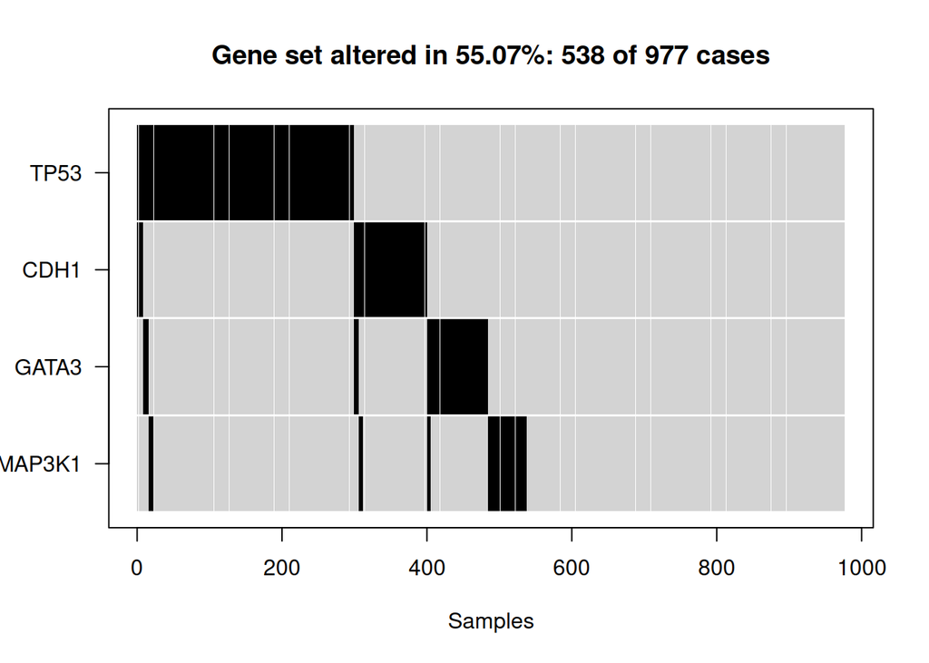

```r
plot(events[genes,])
```

Assort all significant genes (all genes) into a set and look into the result.

```r
result_sig <- as.data.frame(result.mutex)
total_genes <- unique(c(result_sig$gene1, result_sig$gene2))
groupwise.discover.test(events[total_genes, ])
```

```
## Groupwise DISCOVER mutual exclusivity test
##
## method: impurity
## P = 0.9999967
```

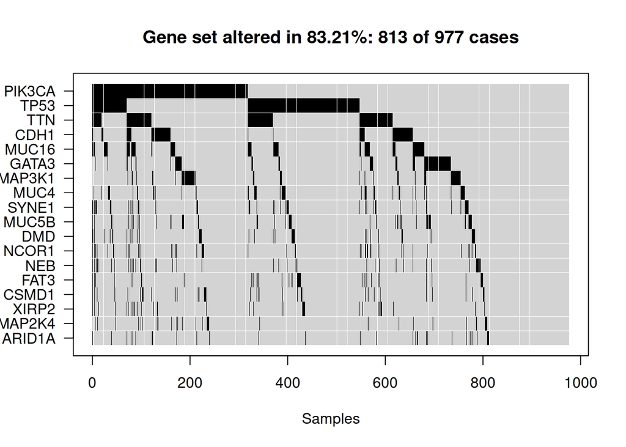

```r
plot(events[total_genes, ])
```

# III. Cancer Mutation Mutual Exclusivity & Coverage Analysis w/ CoMet: Programming Exclusivity and Coverage

## 1. Introduction to CoMet

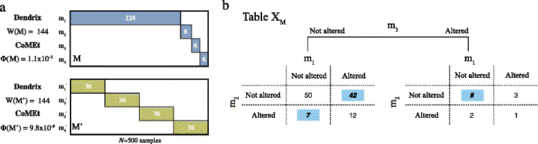

[CoMEt](https://genomebiology.biomedcentral.com/articles/10.1186/s13059-015-0700-7) is an algorithm devised to identify combinations of alterations (mutations) that exhibit a pattern of mutual exclusivity across individuals, often observed in the same pathway. If you look at the figure above, you can see that blue sample set (M) is sampled so that it resembles what you can discover in a typical cancer genome study - where you have a small number of recurrently mutated genes and a long tail of rarely mutated genes. Set M’ (green) has better significance and thus has smaller value of $\phi$, because it exhibits more frequency in each alteration and that raises the CoMEt score. On the right resides the $2\times2\times2$ contingency table $\rm{X}_M$ where you can see that $\rm{m}_1$ and $\rm{m}_2$ alteration status differs according to whether $\rm{m}_3$ is altered or not. The full figure of CoMEt algorithm from the paper itself is placed below.

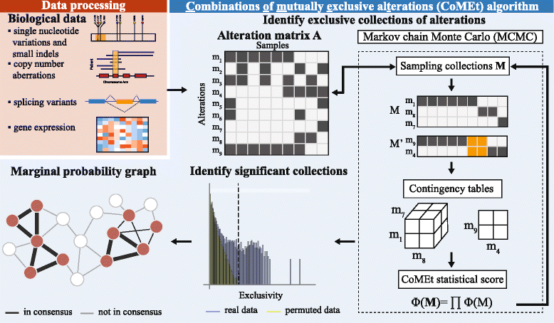

First, an alteration matrix is generated from biological data. Second, Markov Chain Monte Carlo (MCMC) algorithm is used to sample a collection of sets $\rm{M}$, containing *t* sets of *k* alterations, in proportion to the weight $\Phi(\rm{M}^{-\alpha})$. Here we’ve got sets M and M’ in a collection of two sets with three and two alterations respectively. Each collection is scored by $\Phi(\textbf{M})=\prod^t_{i=1}\Phi(M_i)$ Identify all collections whose weight exceeds the maximum observed in randomly permuted datasets (a little bit like a permutation test? In the figure it is denoted as “Identify significant collections”, where such collections that have higher exclusivity score than maximum of randomly permuted real data). Then Marginal probability graph is built to represent the exclusion relationship among gene pairs, where each edge weights indicate the fraction of significant collections with the corresponding pair of alterations. After such graph is built, weak edges are weeded out so that only strongly mutual exclusive gene pairs are left. It seems that this algorithm has improved on MEMo(Mutual Exclusivity Modules) and Dendrix, perhaps? **Not sure. Should look into this a bit more.**

## 2. Practice

```r
# Library Upload
library(cometExactTest)
```

```r
# Mutation matrix (patient by gene)
bm_laml <- bm_laml[,-1] # delete a column at the very beginning where patient ID was present
```

Indexing can suppress one or several rows or columns using negative values. For example, `x[-1,]` will suppress the first row, whereas `x[c(-1, -15),]` will suppress the first and fifteenth rows. Same goes with above expression and `bm_laml[,-1]` suppresses the very first column (gene) of `bm_laml` from being sliced (cited from [R for Beginners by Paradis](https://cran.r-project.org/doc/contrib/Paradis-rdebuts_en.pdf) p. 27.) The first column contained patient (sample) ID info, so for a more convenient analysis it’s much better to exclude this column from the data frame.

```r
# Set preparation (default value is 2)
set_size <-3
geneset_list<-combn(gene, set_size)
```

When `combn(x, m, FUN = NULL, simplify = TRUE, …)`, `combn` function return all combinations of `x` taken `m` at a time. `FUN` designates a specific function where each point will pass through. `simplify=TRUE` means that the return value will be an array or a matrix, but if `simplify=FALSE` it will return a list.[^1]

```r
geneset_list
```

```
##      [,1]     [,2]    [,3]    [,4]    [,5]    [,6]    [,7]    [,8]    [,9]
## [1,] "ASXL1"  "ASXL1" "ASXL1" "ASXL1" "ASXL1" "ASXL1" "ASXL1" "ASXL1" "ASXL1"
## [2,] "CEBPA"  "CEBPA" "CEBPA" "CEBPA" "CEBPA" "CEBPA" "CEBPA" "CEBPA" "CEBPA"
## [3,] "DNMT3A" "GATA2" "IDH2"  "MYC"   "NPM1"  "RAD21" "SRSF2" "TET2"  "TP53"
##      [,10]   [,11]    [,12]    [,13]    [,14]    [,15]    [,16]    [,17]
## [1,] "ASXL1" "ASXL1"  "ASXL1"  "ASXL1"  "ASXL1"  "ASXL1"  "ASXL1"  "ASXL1"
## [2,] "CEBPA" "DNMT3A" "DNMT3A" "DNMT3A" "DNMT3A" "DNMT3A" "DNMT3A" "DNMT3A"
## [3,] "WT1"   "GATA2"  "IDH2"   "MYC"    "NPM1"   "RAD21"  "SRSF2"  "TET2"
##      [,18]    [,19]    [,20]   [,21]   [,22]   [,23]   [,24]   [,25]   [,26]
## [1,] "ASXL1"  "ASXL1"  "ASXL1" "ASXL1" "ASXL1" "ASXL1" "ASXL1" "ASXL1" "ASXL1"
## [2,] "DNMT3A" "DNMT3A" "GATA2" "GATA2" "GATA2" "GATA2" "GATA2" "GATA2" "GATA2"
## [3,] "TP53"   "WT1"    "IDH2"  "MYC"   "NPM1"  "RAD21" "SRSF2" "TET2"  "TP53"
##      [,27]   [,28]   [,29]   [,30]   [,31]   [,32]   [,33]   [,34]   [,35]
## [1,] "ASXL1" "ASXL1" "ASXL1" "ASXL1" "ASXL1" "ASXL1" "ASXL1" "ASXL1" "ASXL1"
## [2,] "GATA2" "IDH2"  "IDH2"  "IDH2"  "IDH2"  "IDH2"  "IDH2"  "IDH2"  "MYC"
```

[output cut: 85 more lines]

```r
# Mutual exclusivity

result_ex <- matrix(ncol=5,nrow=ncol(geneset_list))
colnames(result_ex) <- c("g1", "g2", "g3", "ex_pval", "coverage")
```

```r
for ( g in 1:ncol(geneset_list)){
  laml_ex <- bm_laml[,geneset_list[,g]]
  # Index that particular gene
  g1 <- geneset_list[,g][1]
  g2 <- geneset_list[,g][2]
  g3 <- geneset_list[,g][3]
  # Put those gene set (of 3) into corresponding columns ("g1", "g2", "g3")
  result_ex[g, 1] <- g1
  result_ex[g, 2] <- g2
  result_ex[g, 3] <- g3
  mat <- table(laml_ex[,g3], laml_ex[,g1], laml_ex[,g2])
  mat <- as.vector(mat)

  # adjusted parameter setting (default=1)
  default <- 1
  mat <- mat+default

  # Give exclusive pattern graph drawing option, so
  # that it will generate the graph.
  # The graph will be saved in the current working directory.
  result_ex[g,4] <- comet_exact_test(mat, mutmatplot=TRUE)

  #coverage
  comp <- apply(laml_ex, 1, sum) #laml_ex row-wise sum (sample-wise)
  result_ex[g,5] <- round(length(comp[comp!=0])/length(comp), 2)
  # Number of samples where any mutation exists (elements in comp where != 0)
  # divided by the number of samples (total length of comp).
}
```

In the above code block, the for loop section operates like the following:

```r
laml_ex <- bm_laml[,geneset_list[,1]]
g1 <- geneset_list[,1][1]
g2 <- geneset_list[,1][2]
g3 <- geneset_list[,1][3]
# Put those gene set (of 3) into corresponding columns ("g1", "g2", "g3")
result_ex[1, 1] <- g1
result_ex[1, 2] <- g2
result_ex[1, 3] <- g3
mat <- table(laml_ex[,g3], laml_ex[,g1], laml_ex[,g2])
mat <- as.vector(mat)

# adjusted parameter setting (default=1)
default <- 1
mat
```

```
## [1] 132  47   4   1  10   3   0   0
```

```r
mat <- mat+default
mat
```

```
## [1] 133  48   5   2  11   4   1   1
```

The result is as follows:

```r
head(result_ex)
```

```
##      g1      g2      g3       ex_pval             coverage
## [1,] "ASXL1" "CEBPA" "DNMT3A" "0.699669055726915" "0.33"
## [2,] "ASXL1" "CEBPA" "GATA2"  "0.998901614636291" "0.1"
## [3,] "ASXL1" "CEBPA" "IDH2"   "0.999331411720499" "0.17"
## [4,] "ASXL1" "CEBPA" "MYC"    "0.994559479180605" "0.1"
## [5,] "ASXL1" "CEBPA" "NPM1"   "0.280911860784503" "0.36"
## [6,] "ASXL1" "CEBPA" "RAD21"  "0.976636209393724" "0.12"
```

If I want to view only the significant results,

```r
# significant results
result_ex[result_ex[, 4] < 0.05, ]
```

```
##      g1      g2     g3     ex_pval              coverage
## [1,] "ASXL1" "NPM1" "TP53" "0.0266364567573637" "0.38"
## [2,] "IDH2"  "NPM1" "TP53" "0.021645494887933"  "0.44"
## [3,] "NPM1"  "TET2" "TP53" "0.0188501621203012" "0.43"
```

```r
# Select for only indices of rows that have p-value of less than 0.05,
# which indicates that it's significant.
```

```r
sum(result_ex[,4] < 0.05)
```

```
## [1] 3
```

There are three exclusive gene sets.

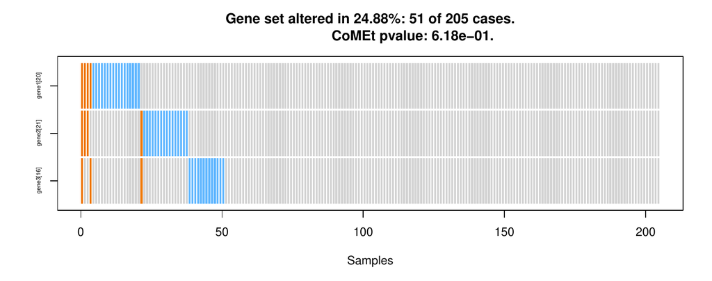

**Why is the resulting values different from the book? This needs to be addressed.**

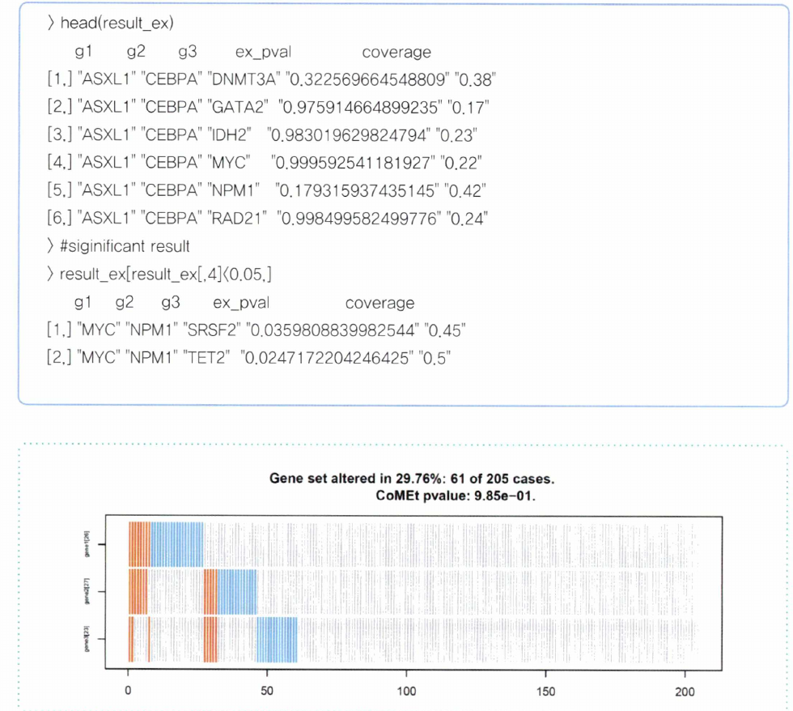

# IV. Visualization of Cancer Genomic Mutations (including mutual exclusivity) with MAFtools and GISTIC

## Introduction to GISTIC (Genomic Identification of Significant Targets in Cancer)

Cancer analysis can be divided into two categories, broadly: SNV/INDEL level mutations and Chromosome/CNV level somatic copy number alteration(SCNA) or structural variation. Traditionally, SCNA analysis have been achieved with microarrays like SNP array or Array CGH (comparative genomic hybridization)[^2]. Nowadays, CNV detection as well as SNV detection is possible through NGS data analysis. GISTIC is a method, algorithm, and software for analyzing CNV with NGS data. In this practice, we learn how to detect CNV and CNV-related mutual exclusivity pattern.

## 1. Load Somatic Mutation Profile

```r
# TCGA somatic mutation profile is loaded.
laml.maf = system.file("extdata", "tcga_laml.maf.gz", package= "maftools")
laml =read.maf(maf = laml.maf, removeSilent = TRUE, useALL= FALSE)
```

There’s a slight error because of unused arguments. I searched it up, and it seems the arguments `removeSilent` and `useALL` are used in [`maftools` v0.99.30](https://www.rdocumentation.org/packages/maftools/versions/0.99.30). However, I have installed from BioConductor the latest version (2.2.10) of `maftools` package in R, as can be seen by applying `packageVersion` function. Instead, newer `read.maf` is as follows:

> read.maf( maf, clinicalData = NULL, removeDuplicatedVariants = TRUE, useAll = TRUE, gisticAllLesionsFile = NULL, gisticAmpGenesFile = NULL, gisticDelGenesFile = NULL, gisticScoresFile = NULL, cnLevel = “all”, cnTable = NULL, isTCGA = FALSE, vc_nonSyn = NULL, verbose = TRUE )

```r
packageVersion("maftools")
```

```
## [1] '2.2.10'
```

The maftools 2.2.10 documentation is at this [link](https://www.bioconductor.org/packages/devel/bioc/vignettes/maftools/inst/doc/maftools.html).

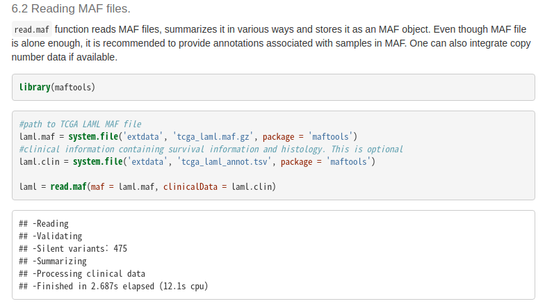

The documentation states that you don’t require any other argument (other than optional clinical data that contains survival information and histology) but only MAF file.

```r
laml.maf = system.file("extdata", "tcga_laml.maf.gz", package="maftools")
laml= read.maf(maf = laml.maf, removeDuplicatedVariants = TRUE, useAll = FALSE)
```

```
## -Reading
## -Validating
## --Using only `Somatic` variants from Mutation_Status. Set useAll = TRUE to include everything.Mutation_Status not found. Assuming all variants are Somatic and validated
## -Silent variants: 475
## -Summarizing
## -Processing clinical data
## --Missing clinical data
## -Finished in 0.177s elapsed (0.245s cpu)
```

Upon googling, I encountered the [repository](https://github.com/PoisonAlien/maftools/tree/master/inst/extdata) of `maftools`, and I have discovered that there are many extra data available within `extdata` directory.

[figure not shown]

Therefore I looked into R directory (`~/R/3.6/maftools/extdata`) and found that there indeed exist all these files.

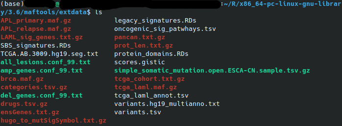

```r
summary(laml)
```

```
## Length  Class   Mode
##      1    MAF     S4
```

```r
str(laml)
```

```
## Formal class 'MAF' [package "maftools"] with 8 slots
##   ..@ data                          :Classes 'data.table' and 'data.frame':  1732 obs. of  17 variables:
##   .. ..$ Hugo_Symbol           : chr [1:1732] "ABCA10" "ABCA4" "ABCB11" "ABCC3" ...
##   .. ..$ Entrez_Gene_Id        : int [1:1732] 10349 24 8647 8714 23 64137 64241 25 55289 92370 ...
##   .. ..$ Center                : chr [1:1732] "genome.wustl.edu" "genome.wustl.edu" "genome.wustl.edu" "genome.wustl.edu" ...
##   .. ..$ NCBI_Build            : int [1:1732] 37 37 37 37 37 37 37 37 37 37 ...
##   .. ..$ Chromosome            : int [1:1732] 17 1 2 17 6 11 2 9 2 3 ...
##   .. ..$ Start_Position        : int [1:1732] 67170917 94490594 169780250 48760974 30554429 119031351 44079555 133760430 111542370 141011154 ...
##   .. ..$ End_Position          : int [1:1732] 67170917 94490594 169780250 48760974 30554429 119031351 44079555 133760430 111542370 141011154 ...
##   .. ..$ Strand                : chr [1:1732] "+" "+" "+" "+" ...
##   .. ..$ Variant_Classification: Factor w/ 7 levels "Frame_Shift_Del",..: 7 5 5 5 5 5 5 5 5 5 ...
##   .. ..$ Variant_Type          : Factor w/ 3 levels "DEL","INS","SNP": 3 3 3 3 3 3 3 3 3 3 ...
##   .. ..$ Reference_Allele      : chr [1:1732] "T" "C" "G" "C" ...
##   .. ..$ Tumor_Seq_Allele1     : chr [1:1732] "T" "C" "G" "C" ...
##   .. ..$ Tumor_Seq_Allele2     : chr [1:1732] "C" "T" "A" "T" ...
##   .. ..$ Tumor_Sample_Barcode  : Factor w/ 193 levels "TCGA-AB-2802",..: 172 63 191 81 112 126 97 183 141 115 ...
##   .. ..$ Protein_Change        : chr [1:1732] "p.K960R" "p.R1517H" "p.A1283V" "p.P1271S" ...
##   .. ..$ i_TumorVAF_WU         : num [1:1732] 45.7 38.1 47 56.4 41 ...
##   .. ..$ i_transcript_name     : chr [1:1732] "NM_080282.3" "NM_000350.2" "NM_003742.2" "NM_003786.1" ...
##   .. ..- attr(*, ".internal.selfref")=<externalptr>
##   ..@ variants.per.sample           :Classes 'data.table' and 'data.frame':  192 obs. of  2 variables:
##   .. ..$ Tumor_Sample_Barcode: Factor w/ 193 levels "TCGA-AB-2802",..: 191 6 147 186 115 156 45 104 119 71 ...
##   .. ..$ Variants            : int [1:192] 34 25 23 21 20 20 20 19 18 18 ...
##   .. ..- attr(*, ".internal.selfref")=<externalptr>
##   ..@ variant.type.summary          :Classes 'data.table' and 'data.frame':  192 obs. of  5 variables:
##   .. ..$ Tumor_Sample_Barcode: Factor w/ 193 levels "TCGA-AB-2802",..: 191 6 147 186 45 115 156 104 71 119 ...
##   .. ..$ DEL                 : int [1:192] 0 2 0 0 0 1 0 0 0 0 ...
##   .. ..$ INS                 : int [1:192] 6 0 0 0 1 1 1 1 1 2 ...
##   .. ..$ SNP                 : int [1:192] 28 23 23 21 19 18 19 18 17 16 ...
##   .. ..$ total               : num [1:192] 34 25 23 21 20 20 20 19 18 18 ...
##   .. ..- attr(*, ".internal.selfref")=<externalptr>
##   ..@ variant.classification.summary:Classes 'data.table' and 'data.frame':  192 obs. of  9 variables:
##   .. ..$ Tumor_Sample_Barcode: Factor w/ 193 levels "TCGA-AB-2802",..: 191 6 147 186 45 115 156 104 71 119 ...
##   .. ..$ Frame_Shift_Del     : int [1:192] 0 1 0 0 0 1 0 0 0 0 ...
##   .. ..$ Frame_Shift_Ins     : int [1:192] 5 0 0 0 1 1 1 1 0 2 ...
##   .. ..$ In_Frame_Del        : int [1:192] 0 1 0 0 0 0 0 0 0 0 ...
##   .. ..$ In_Frame_Ins        : int [1:192] 1 0 0 0 0 0 0 0 1 0 ...
##   .. ..$ Missense_Mutation   : int [1:192] 25 16 22 15 16 15 16 15 17 11 ...
##   .. ..$ Nonsense_Mutation   : int [1:192] 2 3 0 1 1 3 2 1 0 2 ...
##   .. ..$ Splice_Site         : int [1:192] 1 4 1 5 2 0 1 2 0 3 ...
```

[output cut: 28 more lines]

```
##   .. ..$ End_Position          : int [1:475] 48244997 89401084 108009744 50452780 90695109 8808551 156920098 64532572 123071312 73045153 ...
##   .. ..$ Strand                : chr [1:475] "+" "+" "+" "+" ...
##   .. ..$ Variant_Classification: chr [1:475] "Silent" "Silent" "Silent" "Silent" ...
##   .. ..$ Variant_Type          : chr [1:475] "SNP" "SNP" "SNP" "SNP" ...
##   .. ..$ Reference_Allele      : chr [1:475] "G" "C" "T" "C" ...
##   .. ..$ Tumor_Seq_Allele1     : chr [1:475] "G" "C" "T" "C" ...
##   .. ..$ Tumor_Seq_Allele2     : chr [1:475] "A" "T" "G" "G" ...
##   .. ..$ Tumor_Sample_Barcode  : Factor w/ 193 levels "TCGA-AB-2802",..: 27 91 81 191 157 128 16 105 56 29 ...
##   .. ..$ Protein_Change        : chr [1:475] "p.I490I" "p.S1756S" "p.T185T" "p.L77L" ...
##   .. ..$ i_TumorVAF_WU         : num [1:475] 34.27 38.3 49.04 48.1 0.201 ...
##   .. ..$ i_transcript_name     : chr [1:475] "NM_032583.3" "NM_013227.2" "NM_000019.3" "NM_020039.2" ...
##   .. ..- attr(*, ".internal.selfref")=<externalptr>
##   ..@ clinical.data                 :Classes 'data.table' and 'data.frame':  193 obs. of  1 variable:
##   .. ..$ Tumor_Sample_Barcode: Factor w/ 193 levels "TCGA-AB-2802",..: 1 2 3 4 5 6 7 8 9 10 ...
##   .. ..- attr(*, ".internal.selfref")=<externalptr>
```

## 2. Load CNV profile

```r
# Load TCGA CNV data.
all.lesions <- system.file("extdata", "all_lesions.conf_99.txt", package = "maftools") # all lesions
amp.genes <- system.file("extdata", "amp_genes.conf_99.txt", package = "maftools") # amplified genes
del.genes <- system.file("extdata", "del_genes.conf_99.txt", package = "maftools") # deleted genes
scores.gis <- system.file("extdata", "scores.gistic", package = "maftools") # gistic score
laml.gistic <- readGistic(gisticAllLesionsFile= all.lesions, gisticAmpGenesFile = amp.genes, gisticDelGenesFile = del.genes, gisticScoresFile = scores.gis, isTCGA=TRUE)
```

```
## -Processing Gistic files..
## --Processing amp_genes.conf_99.txt
## --Processing del_genes.conf_99.txt
## --Processing scores.gistic
## --Summarizing by samples
```

```r
laml.plus.gistic = read.maf(maf = laml.maf, useAll = FALSE, gisticAllLesionsFile = all.lesions, gisticAmpGenesFile = amp.genes, gisticDelGenesFile = del.genes, gisticScoresFile= scores.gis, isTCGA = TRUE)
```

```
## -Reading
## -Validating
## --Using only `Somatic` variants from Mutation_Status. Set useAll = TRUE to include everything.Mutation_Status not found. Assuming all variants are Somatic and validated
## -Silent variants: 475
## -Processing Gistic files..
## --Processing amp_genes.conf_99.txt
## --Processing del_genes.conf_99.txt
## --Processing scores.gistic
## --Summarizing by samples
## -Summarizing
## -Processing clinical data
## --Missing clinical data
## -Finished in 0.672s elapsed (1.117s cpu)
```

Now get a summary of the sample information.

```r
# sample summary
getSampleSummary(laml)
```

```
##      Tumor_Sample_Barcode Frame_Shift_Del Frame_Shift_Ins In_Frame_Del
##   1:         TCGA-AB-3009               0               5            0
##   2:         TCGA-AB-2807               1               0            1
##   3:         TCGA-AB-2959               0               0            0
##   4:         TCGA-AB-3002               0               0            0
##   5:         TCGA-AB-2849               0               1            0
##  ---
## 188:         TCGA-AB-2933               0               0            0
## 189:         TCGA-AB-2942               0               0            0
## 190:         TCGA-AB-2946               0               0            0
## 191:         TCGA-AB-2954               0               0            0
## 192:         TCGA-AB-2982               0               0            0
##      In_Frame_Ins Missense_Mutation Nonsense_Mutation Splice_Site total
##   1:            1                25                 2           1    34
##   2:            0                16                 3           4    25
##   3:            0                22                 0           1    23
##   4:            0                15                 1           5    21
##   5:            0                16                 1           2    20
##  ---
## 188:            0                 1                 0           0     1
## 189:            1                 0                 0           0     1
## 190:            0                 1                 0           0     1
## 191:            0                 1                 0           0     1
## 192:            0                 1                 0           0     1
```

Now get a summary of mutated genes.

```r
# Mutated genes summary
getGeneSummary(laml)
```

```
##       Hugo_Symbol Frame_Shift_Del Frame_Shift_Ins In_Frame_Del In_Frame_Ins
##    1:        FLT3               0               0            1           33
##    2:      DNMT3A               4               0            0            0
##    3:        NPM1               0              33            0            0
##    4:        IDH2               0               0            0            0
##    5:        IDH1               0               0            0            0
##   ---
## 1237:      ZNF689               0               0            0            0
## 1238:      ZNF75D               0               0            0            0
## 1239:      ZNF827               1               0            0            0
## 1240:       ZNF99               0               0            0            0
## 1241:        ZPBP               0               0            0            0
##       Missense_Mutation Nonsense_Mutation Splice_Site total MutatedSamples
##    1:                15                 0           3    52             52
##    2:                39                 5           6    54             48
```

[output cut: 21 more lines]

```r
getGeneSummary(laml.gistic)
```

```
##       Hugo_Symbol Amp Del total AlteredSamples
##    1:     CTAGE15   0  46    46             23
##    2:     MIR4461   0  36    36             18
##    3:        SHPK   0  30    30             15
##    4:       ABCB8   0  23    23             23
##    5:       ABCF2   0  23    23             23
##   ---
## 2618:       TTLL9   3   0     3              3
## 2619:       UBE2N   0   3     3              3
## 2620:       USP44   0   3     3              3
## 2621:        VEZT   0   3     3              3
## 2622:        XKR7   3   0     3              3
```

```r
getGeneSummary(laml.plus.gistic)
```

```
##       Hugo_Symbol Frame_Shift_Del Frame_Shift_Ins In_Frame_Del In_Frame_Ins
##    1:        FLT3               0               0            1           33
##    2:      DNMT3A               4               0            0            0
##    3:        NPM1               0              33            0            0
##    4:        IDH2               0               0            0            0
##    5:        IDH1               0               0            0            0
##   ---
## 3719:       ZNRF1               0               0            0            0
## 3720:      ZSWIM1               0               0            0            0
## 3721:      ZSWIM3               0               0            0            0
## 3722:         ZYX               0               0            0            0
## 3723:       ZZEF1               0               0            0            0
##       Missense_Mutation Nonsense_Mutation Splice_Site total Amp Del CNV_total
##    1:                15                 0           3    52   0   0         0
##    2:                39                 5           6    54   0   0         0
```

[output cut: 21 more lines]

```r
laml = read.maf(maf = laml.maf, clinicalData = laml.clin)
```

```r
laml.clin <- system.file("extdata", "tcga_laml_annot.tsv", package = "maftools")
```

Now we try `read.maf` function, yet again, **with** `clinicalData`.

```r
laml = read.maf(maf = laml.maf, clinicalData=laml.clin)
```

```
## -Reading
## -Validating
## -Silent variants: 475
## -Summarizing
## -Processing clinical data
## -Finished in 0.163s elapsed (0.249s cpu)
```

```r
laml.gistic = readGistic(gisticAllLesionsFile = all.lesions, gisticAmpGenesFile = amp.genes, gisticDelGenesFile = del.genes, gisticScoresFile = scores.gis, isTCGA=TRUE)
```

```
## -Processing Gistic files..
## --Processing amp_genes.conf_99.txt
## --Processing del_genes.conf_99.txt
## --Processing scores.gistic
## --Summarizing by samples
```

```r
laml.plus.gistic = read.maf(maf = laml.maf, clinicalData = laml.clin, gisticAllLesionsFile = all.lesions, gisticAmpGenesFile = amp.genes, gisticDelGenesFile = del.genes, gisticScoresFile = scores.gis, isTCGA = TRUE)
```

```
## -Reading
## -Validating
## -Silent variants: 475
## -Processing Gistic files..
## --Processing amp_genes.conf_99.txt
## --Processing del_genes.conf_99.txt
## --Processing scores.gistic
## --Summarizing by samples
## -Summarizing
## -Processing clinical data
## -Finished in 0.660s elapsed (1.143s cpu)
```

```r
# included clinical data
```

Get a summary of CNV.

```r
getGeneSummary(laml.gistic)
```

```
##       Hugo_Symbol Amp Del total AlteredSamples
##    1:     CTAGE15   0  46    46             23
##    2:     MIR4461   0  36    36             18
##    3:        SHPK   0  30    30             15
##    4:       ABCB8   0  23    23             23
##    5:       ABCF2   0  23    23             23
##   ---
## 2618:       TTLL9   3   0     3              3
## 2619:       UBE2N   0   3     3              3
## 2620:       USP44   0   3     3              3
## 2621:        VEZT   0   3     3              3
## 2622:        XKR7   3   0     3              3
```

```r
getGeneSummary(laml.plus.gistic)
```

```
##       Hugo_Symbol Frame_Shift_Del Frame_Shift_Ins In_Frame_Del In_Frame_Ins
##    1:        FLT3               0               0            1           33
##    2:      DNMT3A               4               0            0            0
##    3:        NPM1               0              33            0            0
##    4:        IDH2               0               0            0            0
##    5:        IDH1               0               0            0            0
##   ---
## 3719:       ZNRF1               0               0            0            0
## 3720:      ZSWIM1               0               0            0            0
## 3721:      ZSWIM3               0               0            0            0
## 3722:         ZYX               0               0            0            0
## 3723:       ZZEF1               0               0            0            0
##       Missense_Mutation Nonsense_Mutation Splice_Site total Amp Del CNV_total
##    1:                15                 0           3    52   0   0         0
##    2:                39                 5           6    54   0   0         0
```

[output cut: 21 more lines]

## 3. Visualization

Visualize the mutual exclusivity and mutation profile of the cancer genome and print it out as a graph.

### Results

#### Basic Variant Graph

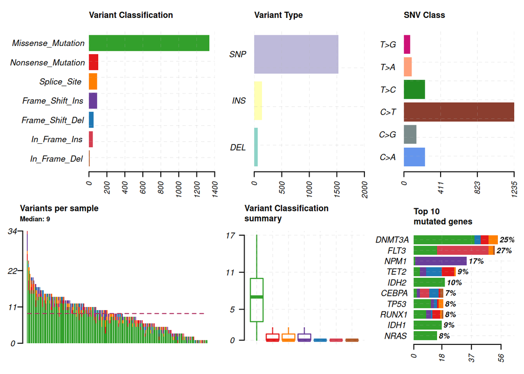

```r
### Caution: If layout breaks, draw each graph separately and turn off R graphics device.

# Draw Out the Basic Variant Graph

plotmafSummary(maf = laml, rmOutlier = TRUE, addStat = 'median', dashboard = TRUE)
```

#### Chromosome-wide Copy Number Graph

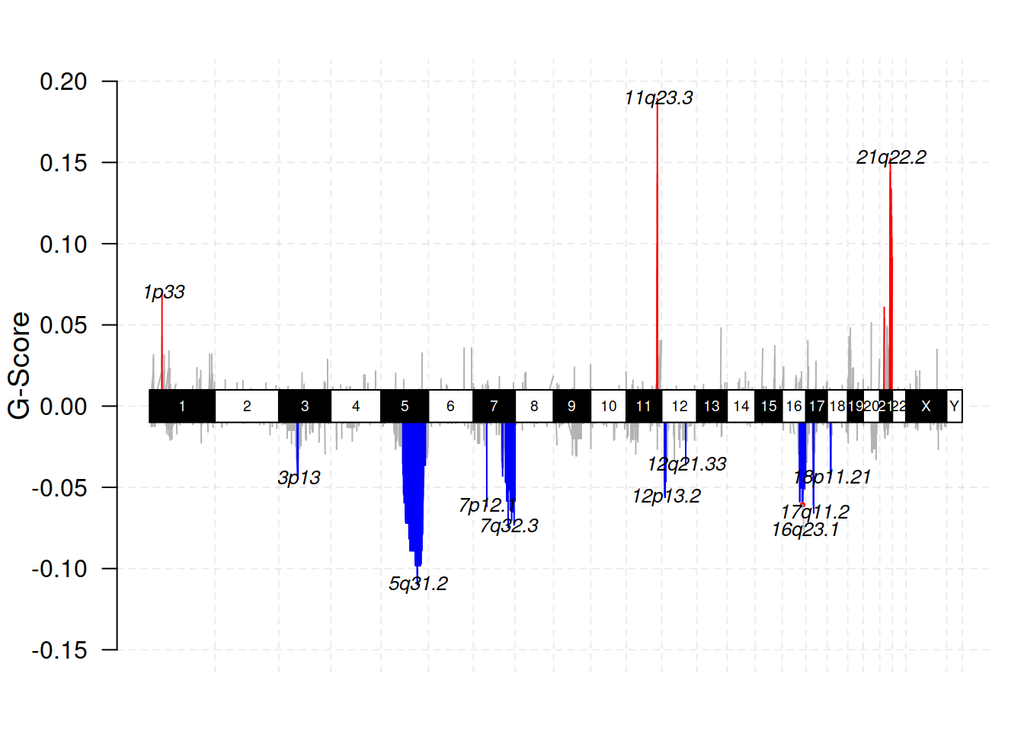

```r
gcp = gisticChromPlot(gistic = laml.gistic, markBands = "all")
```

#### Plot of Top 10 Mutated Genes

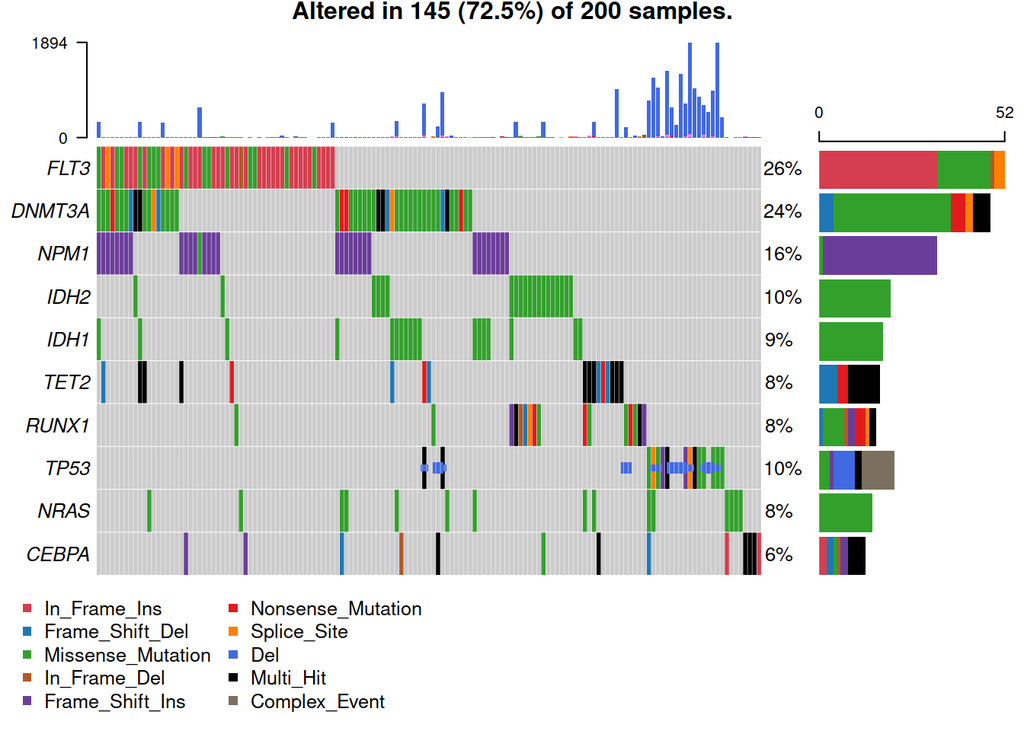

```r
oncoplot(maf = laml.plus.gistic, top = 10, removeNonMutated = TRUE, sortByMutation = TRUE)
```

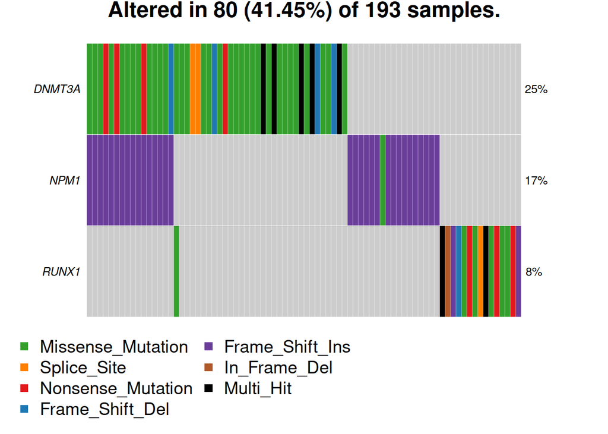

```r
# Oncostrip sounds similar to oncoplot, but it sounds like it strips some data away.
oncostrip(maf = laml, genes = c('DNMT3A', 'NPM1', 'RUNX1'), removeNonMutated=TRUE, showTumorSampleBarcodes=FALSE)
```

**Q: Why is RUNX1 chosen? I don’t understand this part. It looks like that FLT3 must be included.**

#### Ti/Tv ratio

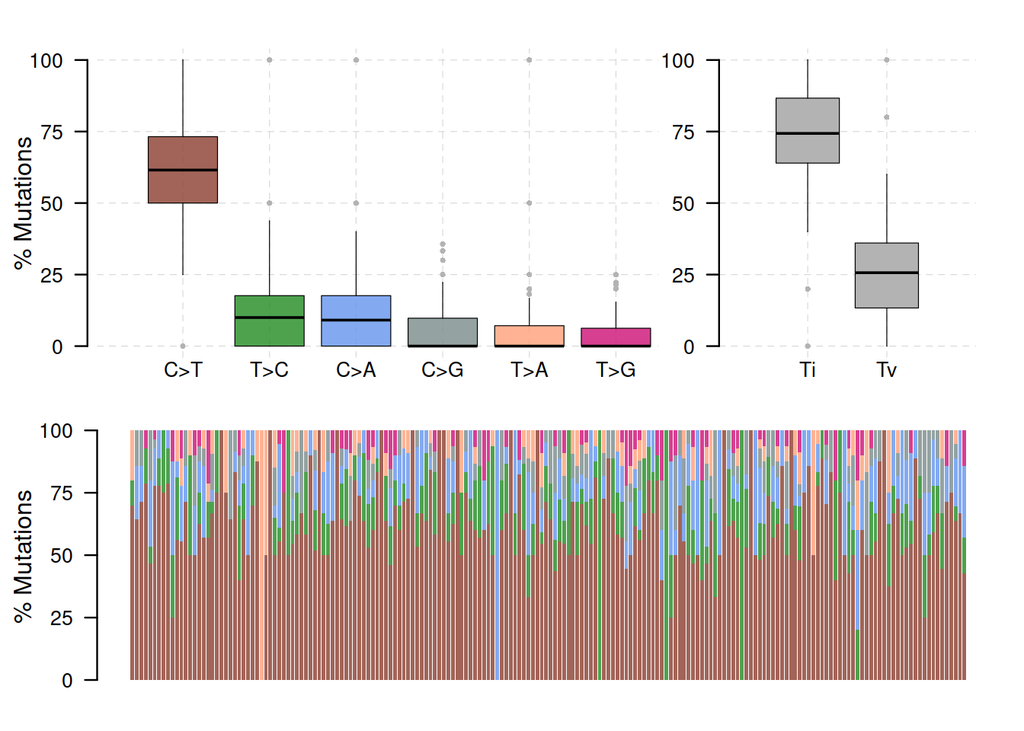

```r
# Ti/Tv ratio
laml.titv = titv(maf = laml, plot = FALSE, useSyn = TRUE)
# plot Ti/Tv summary
plotTiTv(res = laml.titv)
```

[^1]: https://www.rdocumentation.org/packages/utils/versions/3.6.2/topics/combn
[^2]: With an array attached with hundreds or thousands of targeted clones (or nucleotides) attached, comparative analysis is made between control (normal) and case (patient) by looking at different hybridizaation profiles. https://www.nature.com/scitable/topicpage/microarray-based-comparative-genomic-hybridization-acgh-45432/
[^3]: https://bioconductor.org/packages/release/bioc/vignettes/maftools/inst/doc/maftools.html, search for `clinicalData`